# Gentle Introduction to Machine Learning

Module 2: Data Programming

Karl Ho

8/2/2020

[Class link](https://datageneration.org/gentlemachinelearning/)

[Class GitHub](https://github.com/datageneration/gentlemachinelearning)

# 1 What is Data Programming?

Programming is a practice of using programming language to design, perform and evaluate tasks using a computer. These tasks include:

- Computation
- Data collection
- Data management
- Data visualization
- Data modeling

Data programming is a programming practice that focuses on data. It works and evolves with data. In this series, we learn how to design data programs using R (with some Python). Both languages are high-level, interpreted languages that are also objected-oriented and functional. R is the primary language used in this series since it is simple but with a full list of functionalities available through a great number of packages. RStudio is the IDE used and it is free and available in most of the operating systems. It is also available in RStudio Cloud.

# 2 Why Data Programming?

1. Data programming is all about data
2. Data programming is for all to understand
- Programmers tend to adapt other programs without understanding how they work and use “reverse engineering” to figure out what the modules and functions are for.
- Data programming starts from the fundamentals, communicates the purpose of the program and it’s goal-oriented.
3. Data programming is for development (v.0, v.1…)
4. Data programs should be incremental with version control.
5. Data programming is for communication
- Write the program for the first audience: the future you
- Write the program for others: students and collaborators

# 3 Hands-on workshop: K-nearest Neighbor (KNN)

KNN classifier first identifies the $K$ points in the training data that are closest to $x_0$, represented by N0. It then estimates the conditional probability for class j as the fraction of points in (N_)0 whose response values equal $j$

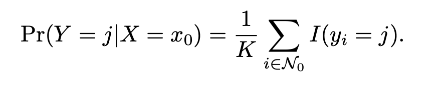

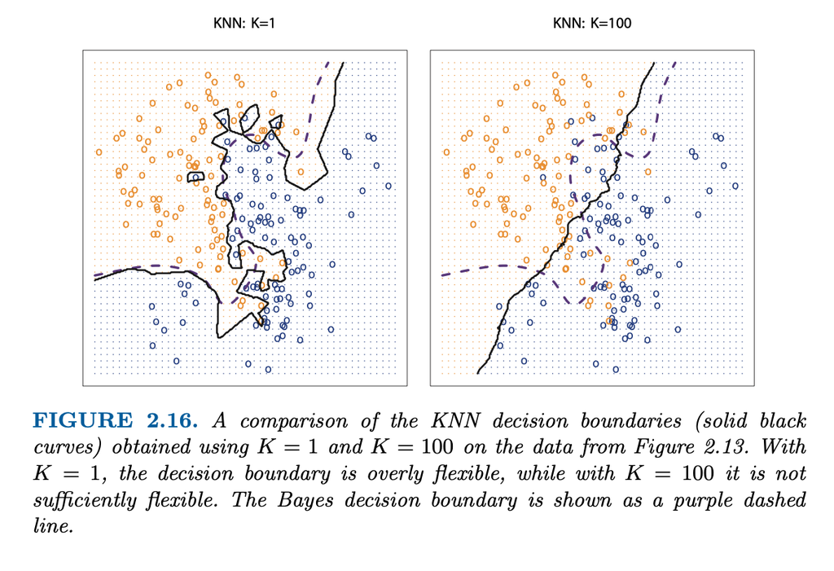

```r
## Gentle Machine Learning
## KNN
## Adapted from James, G., Witten, D., Hastie, T. and Tibshirani, R., 2013.
## An introduction to statistical learning (Vol. 112, p. 18). New York: springer

# install.packages("ISLR")
library(ISLR)
names(Smarket)
```

```
## [1] "Year"      "Lag1"      "Lag2"      "Lag3"      "Lag4"      "Lag5"
## [7] "Volume"    "Today"     "Direction"
```

```r
dim(Smarket)
```

```
## [1] 1250    9
```

```r
summary(Smarket)
```

```
##       Year           Lag1                Lag2                Lag3
##  Min.   :2001   Min.   :-4.922000   Min.   :-4.922000   Min.   :-4.922000
##  1st Qu.:2002   1st Qu.:-0.639500   1st Qu.:-0.639500   1st Qu.:-0.640000
##  Median :2003   Median : 0.039000   Median : 0.039000   Median : 0.038500
##  Mean   :2003   Mean   : 0.003834   Mean   : 0.003919   Mean   : 0.001716
##  3rd Qu.:2004   3rd Qu.: 0.596750   3rd Qu.: 0.596750   3rd Qu.: 0.596750
##  Max.   :2005   Max.   : 5.733000   Max.   : 5.733000   Max.   : 5.733000
##       Lag4                Lag5              Volume           Today
##  Min.   :-4.922000   Min.   :-4.92200   Min.   :0.3561   Min.   :-4.922000
##  1st Qu.:-0.640000   1st Qu.:-0.64000   1st Qu.:1.2574   1st Qu.:-0.639500
##  Median : 0.038500   Median : 0.03850   Median :1.4229   Median : 0.038500
##  Mean   : 0.001636   Mean   : 0.00561   Mean   :1.4783   Mean   : 0.003138
##  3rd Qu.: 0.596750   3rd Qu.: 0.59700   3rd Qu.:1.6417   3rd Qu.: 0.596750
##  Max.   : 5.733000   Max.   : 5.73300   Max.   :3.1525   Max.   : 5.733000
##  Direction
##  Down:602
##  Up  :648
##
##
##
##
```

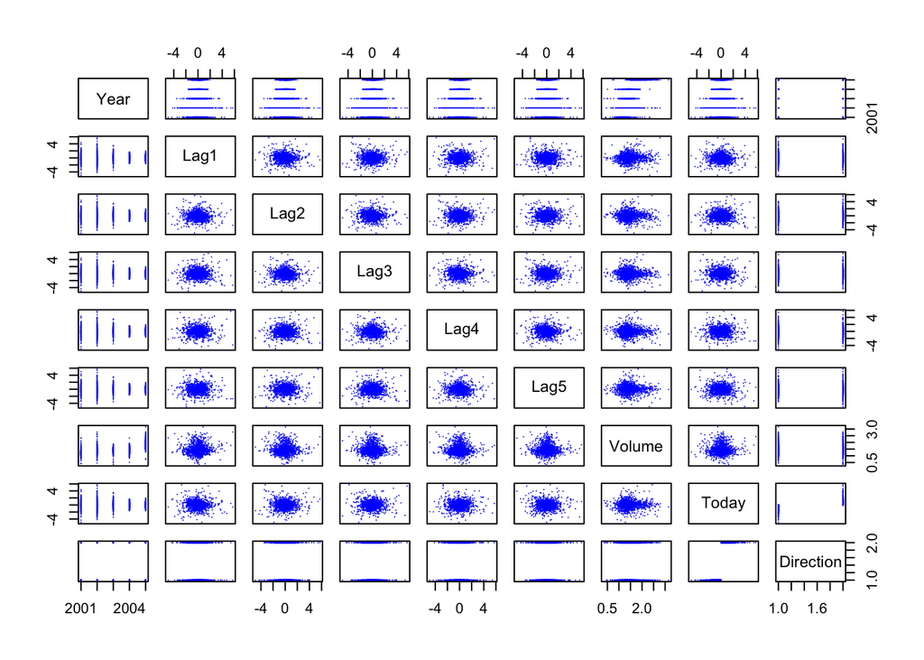

```r
pairs(Smarket, pch=16, cex=.2, col="blue")
```

```r
# cor(Smarket)
cor(Smarket[,-9])
```

```
##              Year         Lag1         Lag2         Lag3         Lag4
## Year   1.00000000  0.029699649  0.030596422  0.033194581  0.035688718
## Lag1   0.02969965  1.000000000 -0.026294328 -0.010803402 -0.002985911
## Lag2   0.03059642 -0.026294328  1.000000000 -0.025896670 -0.010853533
## Lag3   0.03319458 -0.010803402 -0.025896670  1.000000000 -0.024051036
## Lag4   0.03568872 -0.002985911 -0.010853533 -0.024051036  1.000000000
## Lag5   0.02978799 -0.005674606 -0.003557949 -0.018808338 -0.027083641
## Volume 0.53900647  0.040909908 -0.043383215 -0.041823686 -0.048414246
## Today  0.03009523 -0.026155045 -0.010250033 -0.002447647 -0.006899527
##                Lag5      Volume        Today
## Year    0.029787995  0.53900647  0.030095229
## Lag1   -0.005674606  0.04090991 -0.026155045
## Lag2   -0.003557949 -0.04338321 -0.010250033
## Lag3   -0.018808338 -0.04182369 -0.002447647
## Lag4   -0.027083641 -0.04841425 -0.006899527
## Lag5    1.000000000 -0.02200231 -0.034860083
## Volume -0.022002315  1.00000000  0.014591823
## Today  -0.034860083  0.01459182  1.000000000
```

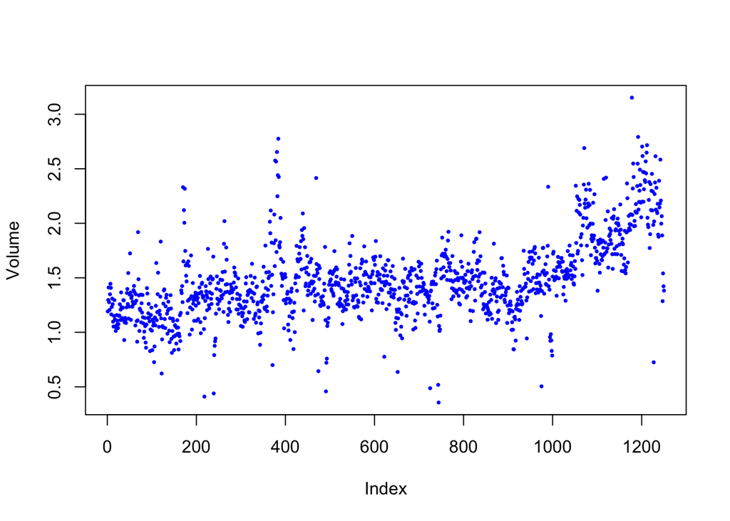

```r
attach(Smarket)
plot(Volume, pch=16, cex=.5, col="blue")
```

```r
# Create training data set
# Note: no reshuffling.  Why?
train=(Year<2005)

# Create testing data sets
Smarket.2005=Smarket[!train,]
Direction.2005=Direction[!train]

library(class)

train.X=cbind(Lag1,Lag2)[train,]
test.X=cbind(Lag1,Lag2)[!train,]
train.Direction=Direction[train]
set.seed(1)

# Running K-nearest Neighbor
# k-nearest neighbour classification for test set from training set.
# For each row of the test set, the k nearest (in Euclidean distance)
# training set vectors are found, and the classification is decided by
# majority vote, with ties broken at random.
# If there are ties for the kth nearest vector, all candidates are
# included in the vote.

knn.pred=knn(train.X,test.X,train.Direction,k=1)

# Confusion matrix
table(knn.pred,Direction.2005)
```

```
##         Direction.2005
## knn.pred Down Up
##     Down   43 58
##     Up     68 83
```

```r
(83+43)/252
```

```
## [1] 0.5
```

```r
knn.pred=knn(train.X,test.X,train.Direction,k=3)
table(knn.pred,Direction.2005)
```

```
##         Direction.2005
## knn.pred Down Up
##     Down   48 54
##     Up     63 87
```

```r
# What is the chance the stock is going up?
mean(knn.pred==Direction.2005)
```

```
## [1] 0.5357143
```